# Gut Microbiota Report Ústí nad Labem

Anton Hagström, Lovisa Hambäck, William Wallén, IBG, Uppsala University

Charlotte Enkvist, Elin Videvall, IEG, Uppsala University

December, 2025

The present report summarizes the gut microbiota profiles of wolverines housed at your institution, based on high-throughput sequencing of the fecal samples you sent us. The results are intended to provide a baseline overview of microbial diversity, composition, and potential patterns observed across individuals. While microbiota data alone cannot diagnose health issues, it can serve as a complementary tool supporting husbandry decisions, dietary evaluations, and long-term welfare assessments.

We thank you for your collaboration and hope that the findings contribute to ongoing efforts to optimize care for captive wolverines and support collaborative knowledge-sharing across institutions.

## Bacterial Composition

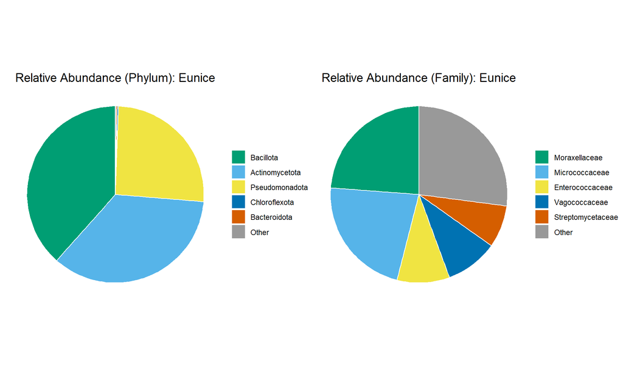

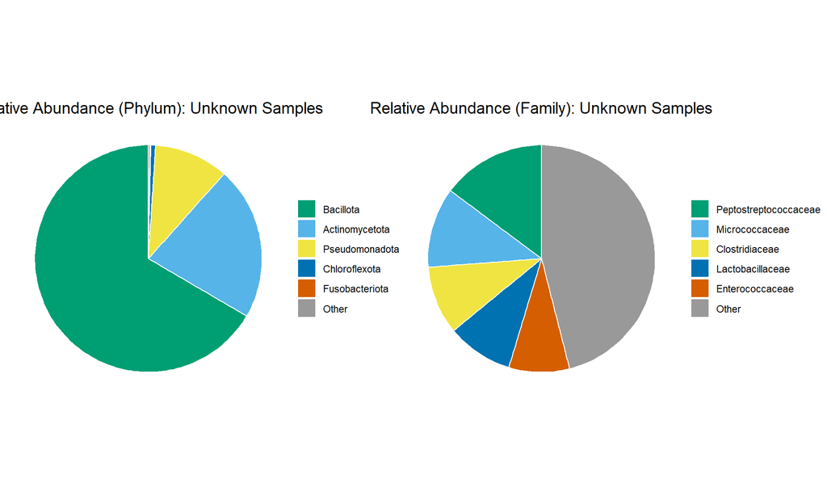

Pie charts showing the composition of gut microbiota for each individual wolverine. For each individual, the left chart displays the relative abundance of bacteria at the phylum level, providing an overview of the main bacterial groups present. The right chart shows the family level, giving a more detailed view of which bacterial families make up the microbiota. The size of each slice represents the proportion of that group in the samples, allowing us to compare which bacteria are most common in each individual.  
The following plot will show you the relative abundance of different phyla for all zoos that participated in this study, so you can see how your individuals varied. The samples were merged per zoo as to provide a relative abundance per zoo instead of per individual.

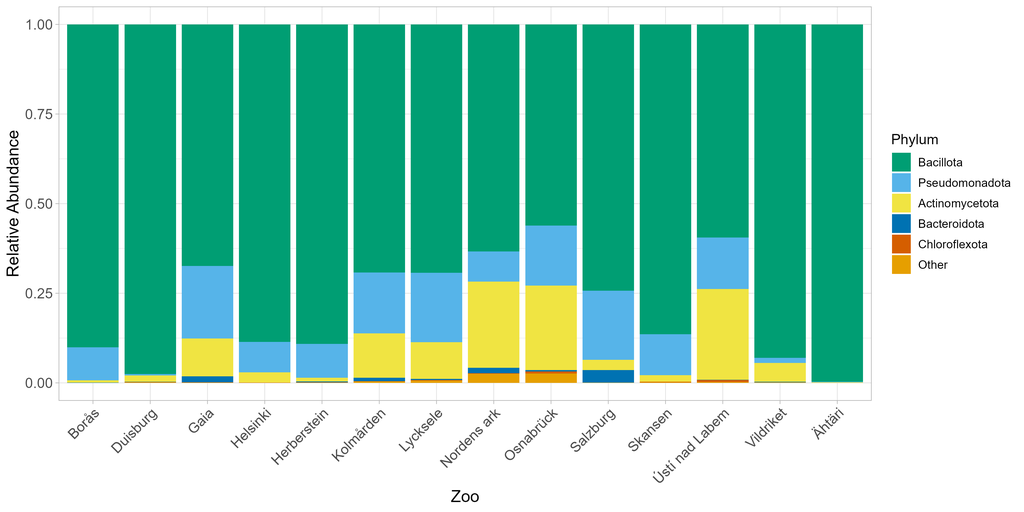

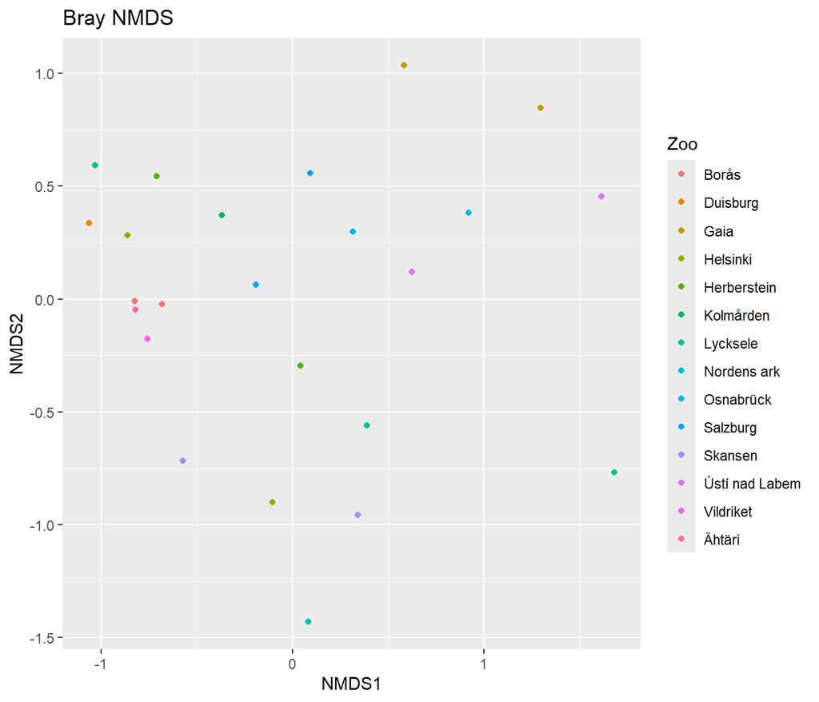

# Alpha Diversity

Alpha diversity describes how many different types of microorganisms are present within a single individual and how evenly these microorganisms are distributed. Higher values generally reflect a more diverse microbial community, but alpha diversity alone does not describe which microorganisms are present or their function.

Your individuals have an alpha diversity of 4.022 and 4.667. Overall, the alpha diversity at your zoo is comparable to that observed in most other zoos.

However, alpha diversity is a summary measure and can be influenced by many factors, including species, diet, age, season, and technical aspects of sampling and analysis. Therefore, alpha diversity should not be interpreted as inherently ‘good’ or ‘bad’, but rather as one piece of information that is best interpreted in context and together with other microbiome measures.